# Presentación del proyecto

2025-08-29

Paquetes

```r
library(tidyverse)
library(knitr)
library(plotly)
library(kableExtra)
library(lorem)
library(xtable)
library(stargazer)
library(ggplot2)
```

```r
# Paleta de colores consistente
colores <- c("#4E79A7", "#F28E2B", "#E15759", "#76B7B2", "#59A14F", "#EDC948")
```

```r
# Leer la base de datos
datos <- read_csv("Base_de_datos_depurada.csv")
```

## Introducción

### Objetivos

**Este análisis se centra en la fuerza laboral de EE.UU. en 2023**

- Caracterizar la población de 16+ y su participación laboral.
- Evaluar los niveles de ingreso en los hogares.
- Analizar la incidencia de la pobreza.
- Explorar la distribución sectorial del empleo.

## 1. Tabla resumen de indicadores

Principales indicadores de la población y economía en EE.UU.

| label_grouping | united_states_estimate | united_states_percent |
| --- | --- | --- |
| Population 16 years and over | 271,122,729 | 271,122,729 |
| In labor force | 173,038,795 | 63.8% |
| Unemployment Rate | (X) | 4.3% |
| In labor force | 81,979,611 | 59.4% |
| Median household income (dollars) | 77,719 | (X) |
| With health insurance coverage | 303,818,345 | 92.1% |
| With health insurance coverage | 134,676,286 | 90.2% |
| With health insurance coverage | 4,921,140 | 76.6% |
| With health insurance coverage | 33,906,425 | 86.2% |
| All people | (X) | 12.5% |

## 2. Gráficos principales

**Participación laboral de la población 16+**

```r
# Limpiar columnas y convertir a numérico
datos <- datos %>%
  mutate(
    united_states_estimate = as.numeric(str_replace_all(united_states_estimate, "[,\\(X\\)]", "")),
    united_states_percent  = as.numeric(str_replace_all(str_remove(united_states_percent, "%"), "[\\(X\\)]", ""))
  )
```

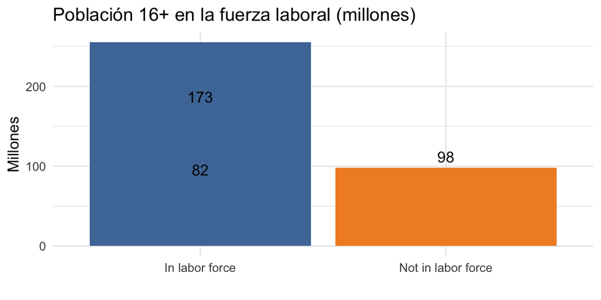

## 3. Gráficos principales

**Distribución de ingresos de los hogares**

### Ingresos medianos de hogares y familias

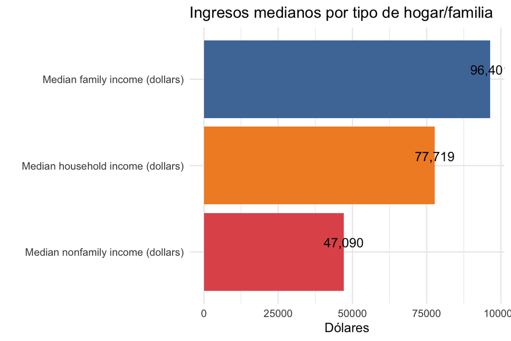

## Gráfico 1: Población 16+ en la fuerza laboral

**Descripción:**  
*Muestra la población estadounidense mayor de 16 años dividida entre quienes están en la fuerza laboral y quienes no participan en ella.*

**Datos principales:**  
- En la fuerza laboral: ~173 millones  
- No en la fuerza laboral: ~98 millones

**Interpretación:**  
- Aproximadamente dos tercios de la población de 16+ participan en la fuerza laboral.  
- Un tercio no participa, lo que incluye estudiantes, jubilados y personas que no buscan trabajo.  
- Esto refleja un nivel de participación laboral relativamente alto y es un indicador importante para entender la dinámica del mercado de trabajo en EE. UU.

## Gráfico 2: Ingresos medianos por tipo de hogar/familia

**Descripción:**  
Compara los ingresos medianos de distintos tipos de hogares en Estados Unidos.

**Datos principales:**  
- Hogares (Median household income): ~77,719 USD  
- Familias (Median family income): ~96,401 USD  
- Hogares no familiares (Median nonfamily income): ~47,090 USD

**Interpretación:**  
- Las familias tienen ingresos medianos más altos que los hogares en general, probablemente porque incluyen más de un ingreso.  
- Los hogares no familiares tienen ingresos significativamente menores.  
- Este gráfico evidencia desigualdades dentro de la población según la composición del hogar y permite identificar los segmentos con menor capacidad económica.